# Fall 2020 - Math 421 - Midterm

## III. Predictive Models

Continue with the data from part I. Use the follows as the target and input variables:

*Target Variable*: Create the target variable taking value of

- `low cost` if the total charge of a patient (`tot`) is smaller than the median of the total charge, and
- `high cost` otherwise.

```r
medtot <- median(midterm2$tot, na.rm = TRUE)
```

```r
medtot
```

```
## [1] 21854
```

```r
midterm2$target <- case_when(midterm2$tot <medtot ~ 'low cost', TRUE ~ 'high cost')
```

*Input Variables*:

- “age”,“sex”,“raceethn”,“provider”,“moa”,“mod”,“admtype”,“campus”, ‘los’

```r
midterm3 <- select(midterm2, age, sex, raceethn, provider, moa, mod, admtype, campus, los, target)
```

1. Use `filter` function to filter out rows where `raceethn==''` or `admtype==''`. Make sure all the categorical variables are factor, numeric variables are numeric. Set Training : Testing Split = 10 : 90

```r
midterm3 %>% filter(!(raceethn=='' | admtype==''))
```

```
## # A tibble: 127,527 x 10
##      age sex   raceethn provider   moa   mod admtype campus   los target
##    <dbl> <chr> <chr>    <chr>    <dbl> <dbl> <chr>   <chr>  <dbl> <chr>
##  1     0 1     1        7214         1     1 4       0          2 low cost
##  2    76 2     1        7214         1     1 3       0          1 high cost
##  3    50 2     1        7214        12     1 2       0          3 high cost
##  4     0 1     7        7214         1     1 4       0          4 low cost
##  5     0 1     1        7214        12     1 4       0         35 high cost
##  6     0 2     9        7214        12     1 4       0         17 high cost
##  7     0 2     1        7214         1     1 4       0          2 low cost
##  8     0 2     1        7214         1     1 4       0          3 low cost
##  9    70 2     1        7214         1     1 2       0          2 high cost
## 10    25 2     1        7214        12     1 2       0         12 high cost
## # ... with 127,517 more rows
```

```r
sapply(midterm3, class)
```

```
##         age         sex    raceethn    provider         moa         mod
##   "numeric" "character" "character" "character"   "numeric"   "numeric"
##     admtype      campus         los      target
## "character" "character"   "numeric" "character"
```

```r
midterm3$target <- factor(midterm3$target)

midterm3$sex <- factor(midterm3$sex)

midterm3$raceethn <- factor(midterm3$raceethn)

midterm3$provider <- factor(midterm3$provider)

midterm3$moa <- factor(midterm3$moa)

midterm3$mod <- factor(midterm3$mod)

midterm3$campus <- factor(midterm3$campus)

midterm3$admtype <- factor(midterm3$admtype)
```

```r
sapply(midterm3, class)
```

```
##       age       sex  raceethn  provider       moa       mod   admtype    campus
## "numeric"  "factor"  "factor"  "factor"  "factor"  "factor"  "factor"  "factor"
##       los    target
## "numeric"  "factor"
```

```r
# Split Data Training Testing #

library(caret)
set.seed(2020)
splitIndex <- createDataPartition(midterm3$target, p = 0.10, list = FALSE)

midterm3_train <- midterm3[ splitIndex,]
midterm3_test <- midterm3[- splitIndex,]
```

2. Train a decision tree using `rpart`. Plot the decision tree. Plot the variable importance ranked by the tree.

```r
# Train Decision Tree #
library(rpart)
mtdt <- rpart(target ~., data = midterm3_train, control = rpart.control(maxdepth = 3))
```

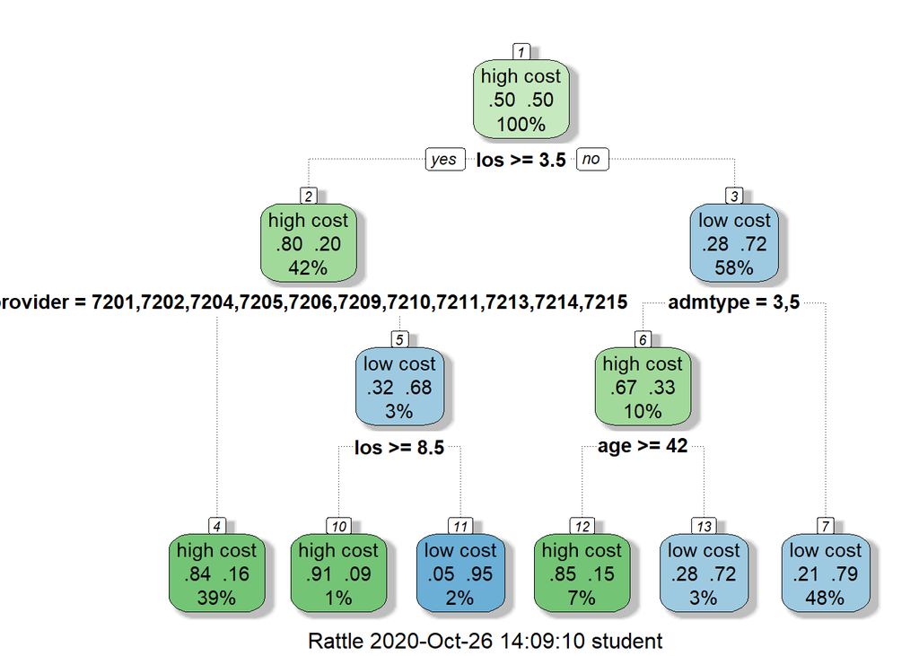

```r
# Plot Tree #
library(rattle)
fancyRpartPlot(mtdt)
```

```r
# Testing Accuracy of Decision Tree #
pred <- predict(mtdt, midterm3_test, type = "class")

cm <- confusionMatrix(data = pred, reference = midterm3_test$target, positive = "high cost")

cm$overall[1]
```

```
##  Accuracy
## 0.8148298
```

```r
# Variable Importance #
mtdt$variable.importance
```

```
##         los     admtype    provider         age      campus    raceethn
## 1830.588014  460.090521  406.667500  228.381227  114.350093   24.032669
##         sex
##    0.792107
```

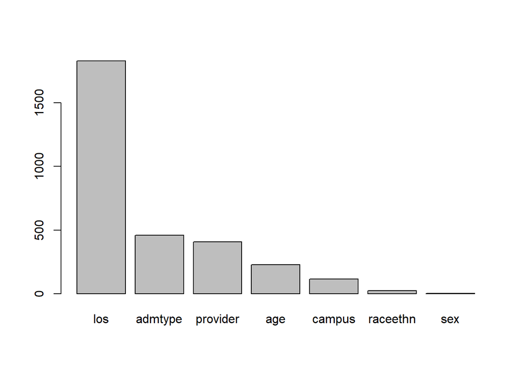

```r
# Plot Variable Importance #
barplot(mtdt$variable.importance)
```

3. Using caret for this question. Set `Training Control` to be: Use Cross-Validation of 5 folds across all models. Train & tune at least 3 different models (i.e. three different values for `method=` in the train function of caret). Plot the hyper-parameter tuning plots for each model.

```r
# Random Forest #
library(caret)
trControl = trainControl(method = "cv", number = 5)

mtrf <- train(target~., data = midterm3_train, method = "rf", trControl = trControl)
```